# Chapter6_岗位薪酬数据集

# 1 案例数据

本案例使用数据分析岗位招聘薪酬数据集。该数据收集自各大招聘网站发布的数据分析岗位招聘的相关信息，共包含了6682条岗位招聘数据。数据集的每一列分别对应：岗位薪资、是否要求掌握R、SPSS、Excel、Python、MATLAB、Java、SQL、SAS、Stata、EViews、Spark、Hadoop、公司类别、公司规模、学历要求、工作经验、公司地点。

```r
> jobinfo <- read.csv("data//jobinfo.csv",header = T,fileEncoding = "utf-8")
```

## 1.1 描述性分析

岗位薪资的描述性分析

```r
> summary(jobinfo$aveSalary)
```

```
   Min. 1st Qu.  Median    Mean 3rd Qu.    Max.
   1500    5250    7000    8048   10000   20000
```

```r
> max(jobinfo$aveSalary)
```

```
[1] 19999.5
```

```r
> jobinfo[which.max(jobinfo$aveSalary),]
```

```
  aveSalary R SPSS Excel Python MATLAB Java SQL SAS Stata EViews Spark Hadoop
1   19999.5 1    0     0      0      0    0   0   1     0      0     0      0
  公司类别    公司规模 学历要求 工作经验   地区
1     国企 1000-5000人     本科        2 北上深
```

绘制岗位薪资的频数直方图

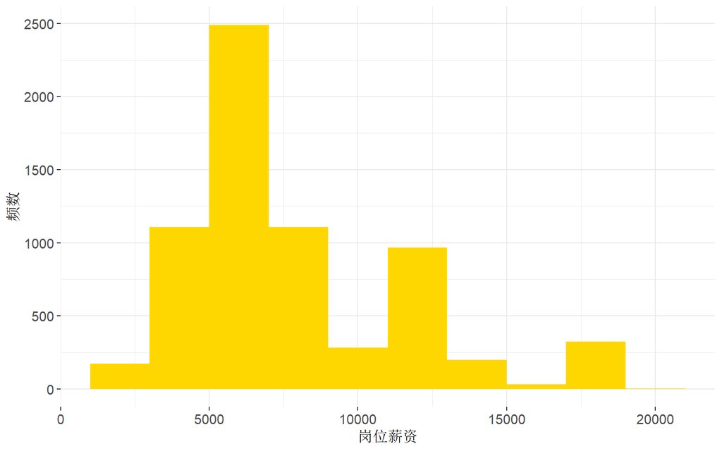

```r
> library(ggplot2)
> ggplot(data = jobinfo,aes(x=aveSalary)) +
+     geom_histogram(binwidth = 2000,fill="gold") +
+     labs(y="频数",x = "岗位薪资") +
+     theme_bw() +
+     theme(panel.border=element_blank(),
+           text = element_text(family = "STHeiti"),
+           axis.title = element_text(size = 12),
+           axis.text = element_text(size = 11))
```

### 1.1.1 岗位学历要求对薪资水平是否有影响

通过箱线图，探究岗位学历要求对薪资水平是否有影响。（提示：为了使得箱线图更加美观，可以对因变量取对数）

```r
> # 利用箱线图画出，学历vs对数平均薪资的分布，箱体的宽度越宽表示样本量越多
> # 将学历转化为因子型变量，便于画图
> jobinfo$学历要求 <- factor(jobinfo$学历要求,levels=c("中专","高中","大专","无","本科","研究生"))
> jobinfo$对数薪资 <- log(jobinfo$aveSalary)
```

```r
> # 计算每个学历要求的岗位薪资的四分位数
> library(dplyr)
> tapply(jobinfo$aveSalary,jobinfo$学历要求,quantile)
```

```
$中专
     0%     25%     50%     75%    100%
 2499.5  3749.5  5249.5  7000.0 14000.0

$高中
      0%      25%      50%      75%     100%
 2499.50  3749.50  5249.50  6999.50 14583.33

$大专
     0%     25%     50%     75%    100%
 1749.5  5000.0  6000.0  8999.5 19000.0

$无
     0%     25%     50%     75%    100%
 1650.0  5249.5  6999.5  8999.5 18500.0

$本科
     0%     25%     50%     75%    100%
 1500.0  6999.5  8999.5 12499.5 19999.5

$研究生
      0%      25%      50%      75%     100%
 2499.50  6999.50  8999.75 12499.50 18750.00
```

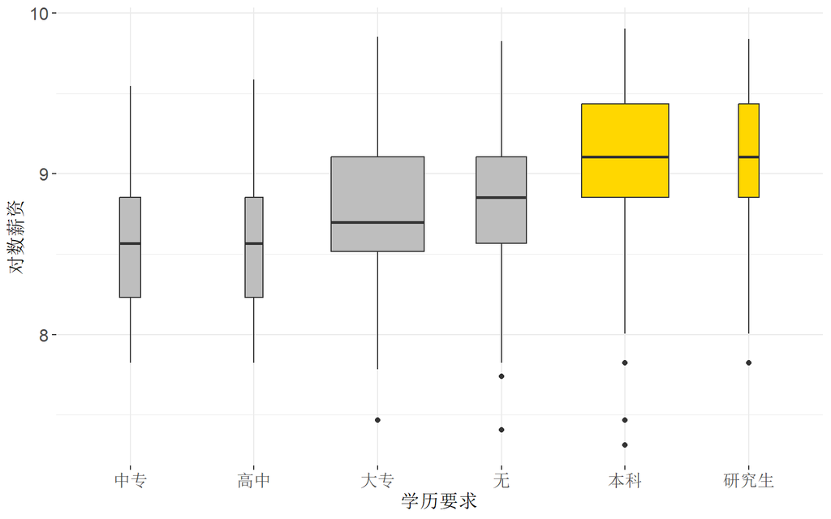

```r
> # 绘制箱线图
> ggplot(jobinfo,aes(学历要求,对数薪资)) +
+         geom_boxplot(varwidth = TRUE, fill = c(rep("grey",4),rep("gold",2))) +
+         labs(x="学历要求", y = "对数薪资")+
+   theme_bw() +
+   theme(panel.border=element_blank(),
+         text = element_text(family = "STHeiti"),
+         axis.title = element_text(size = 13),
+         axis.text = element_text(size = 12))
```

### 1.1.2 Python和SPSS要求与否对薪资水平是否有影响

```r
> library(tidyverse)
> # 是否要求会使用Python
> fct_count(as.factor(jobinfo$Python),prop = TRUE) # prop.table(table(jobinfo$Python))
```

```
# A tibble: 2 × 3
  f         n      p
  <fct> <int>  <dbl>
1 0      6388 0.956
2 1       294 0.0440
```

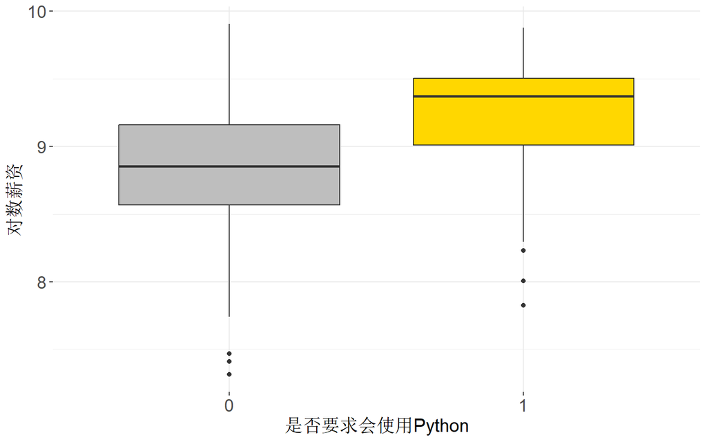

```r
> ggplot(jobinfo,aes(as.factor(Python),对数薪资)) +
+   geom_boxplot(fill = c("grey","gold")) +
+   labs(x="是否要求会使用Python", y = "对数薪资") +
+   theme_bw() +
+   theme(panel.border=element_blank(),
+         text = element_text(family = "STHeiti"),
+         axis.title = element_text(size = 15),
+         axis.text = element_text(size = 14))
```

```r
> # 是否要求会使用SPSS
> fct_count(as.factor(jobinfo$SPSS),prop = TRUE)
```

```
# A tibble: 2 × 3
  f         n      p
  <fct> <int>  <dbl>
1 0      6150 0.920
2 1       532 0.0796
```

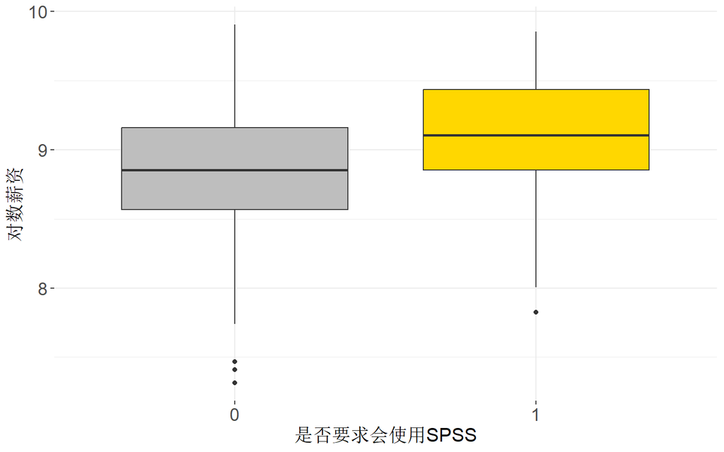

```r
> ggplot(jobinfo,aes(as.factor(SPSS),对数薪资)) +
+   geom_boxplot(fill = c("grey","gold")) +
+   labs(x="是否要求会使用SPSS", y = "对数薪资") +
+   theme_bw() +
+   theme(panel.border=element_blank(),
+         text = element_text(family = "STHeiti"),
+         axis.title = element_text(size = 15),
+         axis.text = element_text(size = 14))
```

# 2 模型形式

## 2.1 自变量离散：0-1自变量

```r
> fit1 <- lm(formula = aveSalary ~ Python, data = jobinfo)
> # fit1 <- lm(formula = aveSalary ~ Python+工作经验+Python*工作经验, data = jobinfo)
> # fit1 <- lm(formula = aveSalary ~ ., data = jobinfo)
> # fit1 <- lm(formula = aveSalary ~ .-Python, data = jobinfo)
> # fit1 <- lm(formula = aveSalary ~ .-1, data = jobinfo)
> summary(fit1)
```

```
Call:
lm(formula = aveSalary ~ Python, data = jobinfo)

Residuals:
    Min      1Q  Median      3Q     Max
-8674.5 -2654.1  -904.1  1596.4 12095.9

Coefficients:
            Estimate Std. Error t value Pr(>|t|)
(Intercept)  7903.61      46.25  170.88   <2e-16 ***
Python       3270.44     220.50   14.83   <2e-16 ***
---
Signif. codes:  0 '***' 0.001 '**' 0.01 '*' 0.05 '.' 0.1 ' ' 1

Residual standard error: 3697 on 6680 degrees of freedom
Multiple R-squared:  0.03188,   Adjusted R-squared:  0.03174
F-statistic:   220 on 1 and 6680 DF,  p-value: < 2.2e-16
```

## 2.2 自变量离散：多水平（例如：公司类别）

```r
> jobinfo$公司类别 <- factor(jobinfo$公司类别,levels=c("国企","合资","外资","上市公司","民营公司","创业公司"))
> fit2 <- lm(formula = aveSalary ~ 公司类别, data = jobinfo)
> summary(fit2)
```

```
Call:
lm(formula = aveSalary ~ 公司类别, data = jobinfo)

Residuals:
    Min      1Q  Median      3Q     Max
-6532.7 -2652.4  -902.4  2098.1 11717.3

Coefficients:
                 Estimate Std. Error t value Pr(>|t|)
(Intercept)       8282.23     244.61  33.859   <2e-16 ***
公司类别合资       306.08     283.48   1.080    0.280
公司类别外资       -81.33     281.01  -0.289    0.772
公司类别上市公司   -99.37     316.79  -0.314    0.754
公司类别民营公司  -380.28     250.78  -1.516    0.129
公司类别创业公司   788.62     480.95   1.640    0.101
---
Signif. codes:  0 '***' 0.001 '**' 0.01 '*' 0.05 '.' 0.1 ' ' 1

Residual standard error: 3750 on 6676 degrees of freedom
Multiple R-squared:  0.004457,  Adjusted R-squared:  0.003711
F-statistic: 5.977 on 5 and 6676 DF,  p-value: 1.596e-05
```

# 3 模型评价与诊断

## 3.1 建立一元线性回归模型

```r
> # 一元线性回归模型
> fit3 <- lm(formula = aveSalary ~ 工作经验, data = jobinfo)
> summary(fit3)
```

```
Call:
lm(formula = aveSalary ~ 工作经验, data = jobinfo)

Residuals:
     Min       1Q   Median       3Q      Max
-10384.8  -2522.2   -997.9   2168.2  12168.7

Coefficients:
            Estimate Std. Error t value Pr(>|t|)
(Intercept)  6831.28      61.03  111.93   <2e-16 ***
工作经验      730.30      25.75   28.36   <2e-16 ***
---
Signif. codes:  0 '***' 0.001 '**' 0.01 '*' 0.05 '.' 0.1 ' ' 1

Residual standard error: 3550 on 6680 degrees of freedom
Multiple R-squared:  0.1074,    Adjusted R-squared:  0.1073
F-statistic: 804.1 on 1 and 6680 DF,  p-value: < 2.2e-16
```

## 3.2 建立多元线性回归模型

首先以岗位薪资为因变量，以地区、公司类别、公司规模、学历、经验要求以及12种软件需求为自变量，探求这些比变量对于薪资的影响，建立回归模型，并利用summary函数查看回归结果。  
在在建立回归模型之前，需要利用公司所在地、公司类别、公司规模、学历要求创建虚拟变量。回归时，公司类别以国企为基准，公司规模以少于50人为基准，学历以无为基准。

```r
> # 转换为factor型变量，公司类别以国企为基准，公司规模以少于50人为基准，学历以无为基准
> jobinfo$公司类别 <- factor(jobinfo$公司类别, levels = c("国企","合资","外资","上市公司","民营公司","创业公司"))
> jobinfo$公司规模 <- factor(jobinfo$公司规模, levels = c("少于50人","50-500人","500-1000人","1000-5000人","5000-10000人","10000人以上"))
> jobinfo$学历要求 <- factor(jobinfo$学历要求, levels = c("无","中专","高中","大专","本科","研究生"))
```

```r
> # 软件要求
> for (i in c(2:13)){
+   jobinfo[,i] <- as.factor(jobinfo[,i])
+ }
```

```r
> lm.fit1 = lm(aveSalary ~ . - 对数薪资, data = jobinfo) # 建立线性模型
> summary(lm.fit1) # 查看回归结果
```

```
Call:
lm(formula = aveSalary ~ . - 对数薪资, data = jobinfo)

Residuals:
     Min       1Q   Median       3Q      Max
-10071.2  -2153.6   -676.5   1654.8  13515.5

Coefficients:
                      Estimate Std. Error t value Pr(>|t|)
(Intercept)           6768.910    254.284  26.619  < 2e-16 ***
R1                     466.596    218.212   2.138  0.03253 *
SPSS1                  423.658    207.874   2.038  0.04158 *
Excel1                -970.032     97.652  -9.934  < 2e-16 ***
Python1                718.776    234.923   3.060  0.00222 **
MATLAB1                -75.241    302.845  -0.248  0.80380
Java1                  568.885    258.771   2.198  0.02795 *
SQL1                  1275.237    148.395   8.594  < 2e-16 ***
SAS1                   332.544    227.232   1.463  0.14339
Stata1               -1062.972    814.138  -1.306  0.19172
EViews1                419.079    844.015   0.497  0.61954
Spark1                  -3.709    436.855  -0.008  0.99323
Hadoop1               1736.165    330.751   5.249 1.58e-07 ***
公司类别合资           723.833    236.596   3.059  0.00223 **
公司类别外资           293.873    234.330   1.254  0.20985
公司类别上市公司       597.552    264.734   2.257  0.02403 *
公司类别民营公司       378.531    211.465   1.790  0.07349 .
公司类别创业公司       893.262    402.988   2.217  0.02668 *
公司规模50-500人       282.346    111.355   2.536  0.01125 *
公司规模500-1000人      77.016    149.989   0.513  0.60763
公司规模1000-5000人    427.060    156.551   2.728  0.00639 **
公司规模5000-10000人   339.565    278.032   1.221  0.22201
公司规模10000人以上    329.871    229.577   1.437  0.15080
学历要求中专         -1432.439    272.913  -5.249 1.58e-07 ***
学历要求高中         -1626.832    318.650  -5.105 3.39e-07 ***
学历要求大专          -930.555    121.848  -7.637 2.53e-14 ***
学历要求本科           776.026    126.739   6.123 9.71e-10 ***
学历要求研究生        1725.095    286.849   6.014 1.91e-09 ***
工作经验               682.515     23.073  29.580  < 2e-16 ***
地区非北上深         -2515.269    102.062 -24.645  < 2e-16 ***
---
Signif. codes:  0 '***' 0.001 '**' 0.01 '*' 0.05 '.' 0.1 ' ' 1

Residual standard error: 3105 on 6652 degrees of freedom
Multiple R-squared:  0.3199,    Adjusted R-squared:  0.3169
F-statistic: 107.9 on 29 and 6652 DF,  p-value: < 2.2e-16
```

## 3.3 模型诊断

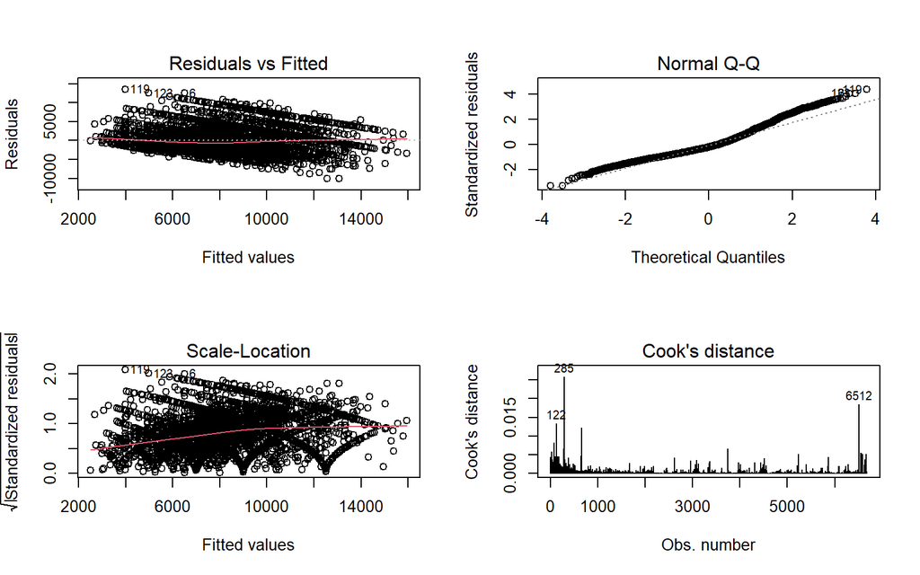

```r
> par(mfrow=c(2,2))
> plot(lm.fit1, which = c(1:4))
```

```markdown
(1)左上图为残差与拟合值的散点图，若因变量和自变量呈现线性相关的关系，则残差值与拟合值没有任何的系统关联。图中所示残差并不随着拟合值的变化呈现规律性变化，因此基本满足线性假设；
(2)右上图为正态Q-Q图，当因变量服从正态分布时，图中的散点应该落在呈45度倾斜的直线上。根据图示，模型中的残差项在较大值的部分偏离直线，因此较大程度上偏离了正态分布；
(3)左下图为位置尺度图，若满足同方差假定，则水平线周围的点应呈现无规律随机分布，根据图中所示，随着拟合值增大，标准化残差呈现升高的规律，表明存在一定的异方差问题；
(4)右下图为样本点的库克距离，其最大值未超过0.05，因此认为样本中不存在异常点。
```

比图形诊断更可靠的是对残差做一些统计检验

```r
> ## 残差的正态性检验
> ks.test(lm.fit1$residuals,"pnorm")
```

```
    Asymptotic one-sample Kolmogorov-Smirnov test

data:  lm.fit1$residuals
D = 0.59503, p-value < 2.2e-16
alternative hypothesis: two-sided
```

```r
> # shapiro.test(lm.fit1$residuals) 适用样本数小于5000
> # Jarque-Bera test
> # Jarque-Bera test的原假设: 序列服从正态分布
> # Jarque-Bera test的备择假设: 序列不服从正态分布
> # 若P值小于0.05，该序列不服从正态分布
> library("tseries")
> jarque.bera.test(lm.fit1$residuals)
```

```
    Jarque Bera Test

data:  lm.fit1$residuals
X-squared = 997.5, df = 2, p-value < 2.2e-16
```

```r
> ## 残差的独立性检验
> library(lmtest)
> dwtest(lm.fit1) # 若p值远小于0.05，也就是说模型中的残差存在自相关
```

```
    Durbin-Watson test

data:  lm.fit1
DW = 0.48616, p-value < 2.2e-16
alternative hypothesis: true autocorrelation is greater than 0
```

```r
> ## 残差的异方差检验
> bptest(lm.fit1) # 若p值远小于0.05，故拒绝同方差的原假设，认为模型存在异方差，这时OLS得到的模型参数虽然是无偏的，但却不再有效
```

```
    studentized Breusch-Pagan test

data:  lm.fit1
BP = 218.15, df = 29, p-value < 2.2e-16
```

```r
> library(gvlma)
> gvmodel <- gvlma(lm.fit1)
> summary(gvmodel)
```

```
Call:
lm(formula = aveSalary ~ . - 对数薪资, data = jobinfo)

Residuals:
     Min       1Q   Median       3Q      Max
-10071.2  -2153.6   -676.5   1654.8  13515.5

Coefficients:
                      Estimate Std. Error t value Pr(>|t|)
(Intercept)           6768.910    254.284  26.619  < 2e-16 ***
R1                     466.596    218.212   2.138  0.03253 *
SPSS1                  423.658    207.874   2.038  0.04158 *
Excel1                -970.032     97.652  -9.934  < 2e-16 ***
Python1                718.776    234.923   3.060  0.00222 **
MATLAB1                -75.241    302.845  -0.248  0.80380
Java1                  568.885    258.771   2.198  0.02795 *
SQL1                  1275.237    148.395   8.594  < 2e-16 ***
SAS1                   332.544    227.232   1.463  0.14339
Stata1               -1062.972    814.138  -1.306  0.19172
EViews1                419.079    844.015   0.497  0.61954
Spark1                  -3.709    436.855  -0.008  0.99323
Hadoop1               1736.165    330.751   5.249 1.58e-07 ***
公司类别合资           723.833    236.596   3.059  0.00223 **
公司类别外资           293.873    234.330   1.254  0.20985
公司类别上市公司       597.552    264.734   2.257  0.02403 *
公司类别民营公司       378.531    211.465   1.790  0.07349 .
公司类别创业公司       893.262    402.988   2.217  0.02668 *
公司规模50-500人       282.346    111.355   2.536  0.01125 *
公司规模500-1000人      77.016    149.989   0.513  0.60763
公司规模1000-5000人    427.060    156.551   2.728  0.00639 **
公司规模5000-10000人   339.565    278.032   1.221  0.22201
公司规模10000人以上    329.871    229.577   1.437  0.15080
学历要求中专         -1432.439    272.913  -5.249 1.58e-07 ***
学历要求高中         -1626.832    318.650  -5.105 3.39e-07 ***
学历要求大专          -930.555    121.848  -7.637 2.53e-14 ***
学历要求本科           776.026    126.739   6.123 9.71e-10 ***
学历要求研究生        1725.095    286.849   6.014 1.91e-09 ***
工作经验               682.515     23.073  29.580  < 2e-16 ***
地区非北上深         -2515.269    102.062 -24.645  < 2e-16 ***
---
Signif. codes:  0 '***' 0.001 '**' 0.01 '*' 0.05 '.' 0.1 ' ' 1

Residual standard error: 3105 on 6652 degrees of freedom
Multiple R-squared:  0.3199,    Adjusted R-squared:  0.3169
F-statistic: 107.9 on 29 and 6652 DF,  p-value: < 2.2e-16


ASSESSMENT OF THE LINEAR MODEL ASSUMPTIONS
USING THE GLOBAL TEST ON 4 DEGREES-OF-FREEDOM:
Level of Significance =  0.05

Call:
 gvlma(x = lm.fit1)

                     Value   p-value                   Decision
Global Stat        2128.47 0.0000000 Assumptions NOT satisfied!
Skewness            846.76 0.0000000 Assumptions NOT satisfied!
Kurtosis            150.74 0.0000000 Assumptions NOT satisfied!
Link Function        11.37 0.0007446 Assumptions NOT satisfied!
Heteroscedasticity 1119.60 0.0000000 Assumptions NOT satisfied!
```

## 3.4 模型修正与模型选择

可将因变量进行对数变换，重新拟合回归模型，使用BIC准则对变量进行选择，并对变量选择后的模型结果进行解读。

```r
> # 计算对数因变量
> jobinfo$对数薪资 <- log(jobinfo$aveSalary)
```

```r
> lm.fit2 <- lm(对数薪资 ~ .- aveSalary, data = jobinfo) # 建立对数线性模型，剔除平均薪资变量
> summary(lm.fit2) # 查看回归结果
```

```
Call:
lm(formula = 对数薪资 ~ . - aveSalary, data = jobinfo)

Residuals:
     Min       1Q   Median       3Q      Max
-1.59999 -0.26299 -0.02898  0.25620  1.43210

Coefficients:
                      Estimate Std. Error t value Pr(>|t|)
(Intercept)           8.753373   0.030511 286.892  < 2e-16 ***
R1                    0.032774   0.026183   1.252  0.21071
SPSS1                 0.055665   0.024942   2.232  0.02566 *
Excel1               -0.117507   0.011717 -10.029  < 2e-16 ***
Python1               0.083433   0.028188   2.960  0.00309 **
MATLAB1              -0.006056   0.036338  -0.167  0.86765
Java1                 0.069968   0.031050   2.253  0.02426 *
SQL1                  0.147355   0.017806   8.276  < 2e-16 ***
SAS1                  0.046839   0.027265   1.718  0.08586 .
Stata1               -0.123253   0.097687  -1.262  0.20710
EViews1               0.039811   0.101272   0.393  0.69425
Spark1               -0.037998   0.052417  -0.725  0.46853
Hadoop1               0.179699   0.039686   4.528 6.06e-06 ***
公司类别合资          0.087100   0.028389   3.068  0.00216 **
公司类别外资          0.025907   0.028117   0.921  0.35686
公司类别上市公司      0.074514   0.031765   2.346  0.01902 *
公司类别民营公司      0.041935   0.025373   1.653  0.09844 .
公司类别创业公司      0.103932   0.048354   2.149  0.03164 *
公司规模50-500人      0.034777   0.013361   2.603  0.00927 **
公司规模500-1000人    0.017690   0.017997   0.983  0.32567
公司规模1000-5000人   0.044287   0.018784   2.358  0.01842 *
公司规模5000-10000人  0.045901   0.033361   1.376  0.16890
公司规模10000人以上   0.048603   0.027546   1.764  0.07771 .
学历要求中专         -0.200786   0.032746  -6.132 9.20e-10 ***
学历要求高中         -0.223217   0.038234  -5.838 5.53e-09 ***
学历要求大专         -0.117711   0.014620  -8.051 9.64e-16 ***
学历要求本科          0.090812   0.015207   5.972 2.47e-09 ***
学历要求研究生        0.201236   0.034418   5.847 5.25e-09 ***
工作经验              0.084425   0.002769  30.495  < 2e-16 ***
地区非北上深         -0.374549   0.012246 -30.585  < 2e-16 ***
---
Signif. codes:  0 '***' 0.001 '**' 0.01 '*' 0.05 '.' 0.1 ' ' 1

Residual standard error: 0.3725 on 6652 degrees of freedom
Multiple R-squared:  0.3476,    Adjusted R-squared:  0.3448
F-statistic: 122.2 on 29 and 6652 DF,  p-value: < 2.2e-16
```

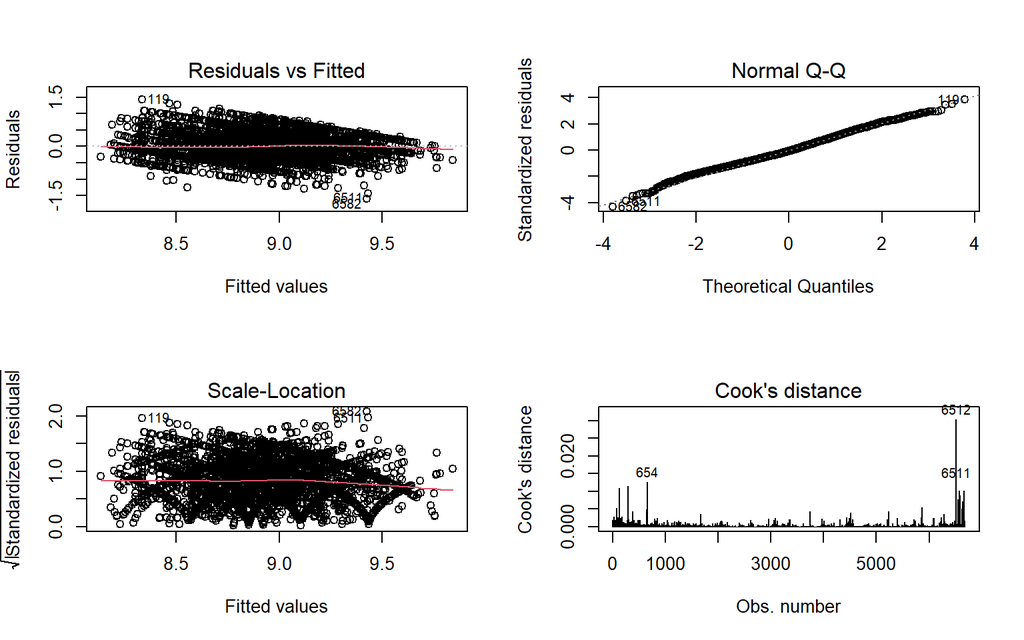

```r
> # 模型诊断
> par(mfrow=c(2,2))
> plot(lm.fit2, which = c(1:4)) # 回归模型的异方差和非正态性都得到了改善
```

```r
> # 多重共线性
> library(DAAG)
> vif(lm.fit2) # 所有变量的VIF值都小于10，因此认为自变量不存在较强的多重共线性
```

```
                  R1                SPSS1               Excel1
              1.9138               2.1948               1.1146
             Python1              MATLAB1                Java1
              1.6090               1.2310               1.4519
                SQL1                 SAS1               Stata1
              1.3385               2.3449               1.0974
             EViews1               Spark1              Hadoop1
              1.0323               1.7191               1.8908
        公司类别合资         公司类别外资     公司类别上市公司
              3.5698               3.7260               2.3917
    公司类别民营公司     公司类别创业公司     公司规模50-500人
              6.6519               1.3644               2.1190
  公司规模500-1000人  公司规模1000-5000人 公司规模5000-10000人
              1.6593               1.6808               1.1451
 公司规模10000人以上         学历要求中专         学历要求高中
              1.2954               1.1550               1.1191
        学历要求大专         学历要求本科       学历要求研究生
              2.5233               2.6254               1.1862
            工作经验         地区非北上深
              1.0490               1.0905
```

```r
> # 使用BIC准则选择模型
> n <- nrow(jobinfo)
> lm.bic <- step(lm.fit2, direction = "both", k = log(n), trace = F) # R语言中step()函数是以AIC信息统计量为准则, 通过选择最小的AIC信息统计量, 来达到剔除或添加变量的目的. k默认为2,输出为AIC值; 设置k为log(n)时输出BIC或SBC值
> summary(lm.bic)
```

```
Call:
lm(formula = 对数薪资 ~ SPSS + Excel + Python + SQL + Hadoop +
    学历要求 + 工作经验 + 地区, data = jobinfo)

Residuals:
     Min       1Q   Median       3Q      Max
-1.54248 -0.25992 -0.02571  0.25825  1.43138

Coefficients:
                Estimate Std. Error t value Pr(>|t|)
(Intercept)     8.827384   0.013680 645.276  < 2e-16 ***
SPSS1           0.092435   0.018706   4.941 7.94e-07 ***
Excel1         -0.117721   0.011646 -10.108  < 2e-16 ***
Python1         0.110596   0.024510   4.512 6.53e-06 ***
SQL1            0.160374   0.017389   9.223  < 2e-16 ***
Hadoop1         0.191131   0.030947   6.176 6.96e-10 ***
学历要求中专   -0.202515   0.032791  -6.176 6.97e-10 ***
学历要求高中   -0.223880   0.038146  -5.869 4.60e-09 ***
学历要求大专   -0.116834   0.014630  -7.986 1.63e-15 ***
学历要求本科    0.094769   0.015130   6.263 4.00e-10 ***
学历要求研究生  0.201863   0.034147   5.912 3.56e-09 ***
工作经验        0.084348   0.002766  30.496  < 2e-16 ***
地区非北上深   -0.371999   0.011976 -31.061  < 2e-16 ***
---
Signif. codes:  0 '***' 0.001 '**' 0.01 '*' 0.05 '.' 0.1 ' ' 1

Residual standard error: 0.3732 on 6669 degrees of freedom
Multiple R-squared:  0.3436,    Adjusted R-squared:  0.3424
F-statistic: 290.9 on 12 and 6669 DF,  p-value: < 2.2e-16
```

- 在控制其他因素不变的情况下，对数据分析人员的工作经验年限要求每多一年，相应岗位的薪资就平均高出8.4%。
- 说明要求掌握Python的岗位，薪资平均比不要求掌握Python的岗位高出11.1%，这和之前的描述分析趋势是吻合的。
- 自变量“学历要求”的基准水平为“无”，那么“研究生”对应的系数0.202可解读为：要求研究生学历的岗位薪资平均比不要求任何学历的岗位高20.2%。

# 4 模型预测

假设有一份北京市上市公司数据分析岗位的工作，该公司为1500人的中小型公司，这个工作要求申请人掌握R、Python、SQL和Hadoop的技能，并且有至少3年的工作经验，最低学历为硕士。希望通过模型预测该岗位的薪资。

```r
> # 新样本
> testdata <- data.frame(R = 1, SPSS = 0, Excel = 0, Python = 1, MATLAB = 0, Java = 0, SQL = 1, SAS = 0, Stata = 0, EViews = 0, Spark = 0, Hadoop = 1, 公司类别 = "上市公司", 公司规模 = "1000-5000人", 学历要求 = "研究生", 工作经验 = 3, 地区 = "北上深")
```

```r
> # 将软件技能转换为factor类型
> for (i in c(1:12)) {
+     testdata[,i] <- as.factor(testdata[,i])
+ }
```

```r
> logsalary_hat <- predict(lm.bic, newdata = testdata)  # 预测值
> sigma_hat2 <- sum(lm.bic$residuals^2)/lm.bic$df.residual  # sigma^2估计值
> y_hat <- exp(logsalary_hat + sigma_hat2/2)
> cat("平均薪资水平约为", round(y_hat, 2), "元/月")
```

```
平均薪资水平约为 18288.72 元/月
```